[figure not shown]

# Activation Functions

## Table of Contents

- Logistic Function
- Tanh
- Relu
- Compare Activation Functions

Estimated Time Needed: **15 min**

We'll need the following libraries

```python
# Import the libraries we need for this lab

import torch.nn as nn
import torch

import matplotlib.pyplot as plt
torch.manual_seed(2)
```

```
<torch._C.Generator at 0x7f07180e11d0>
```

## Logistic Function

Create a tensor ranging from -10 to 10:

```python
# Create a tensor

z = torch.arange(-10, 10, 0.1,).view(-1, 1)
```

When you use sequential, you can create a sigmoid object:

```python
# Create a sigmoid object

sig = nn.Sigmoid()
```

Apply the element-wise function Sigmoid with the object:

```python
# Make a prediction of sigmoid function

yhat = sig(z)
```

Plot the results:

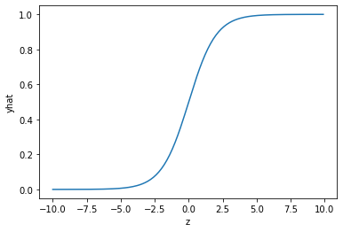

```python
# Plot the result

plt.plot(z.detach().numpy(),yhat.detach().numpy())
plt.xlabel('z')
plt.ylabel('yhat')
```

For custom modules, call the sigmoid from the torch (`nn.functional` for the old version), which applies the element-wise sigmoid from the function module and plots the results:

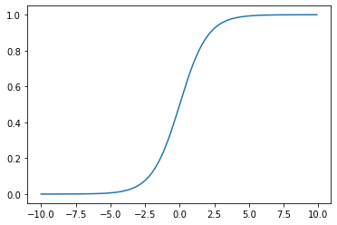

```python
# Use the build in function to predict the result

yhat = torch.sigmoid(z)
plt.plot(z.numpy(), yhat.numpy())

plt.show()
```

## Tanh

When you use sequential, you can create a tanh object:

```python
# Create a tanh object

TANH = nn.Tanh()
```

Call the object and plot it:

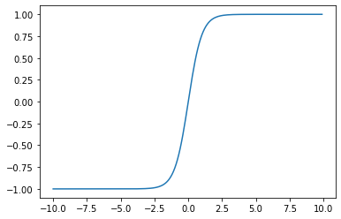

```python
# Make the prediction using tanh object

yhat = TANH(z)
plt.plot(z.numpy(), yhat.numpy())
plt.show()
```

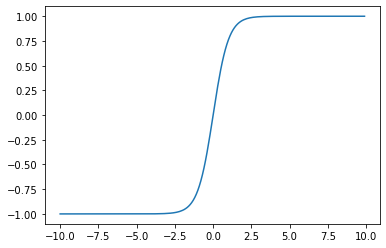

```python
# Make the prediction using the build-in tanh object

yhat = torch.tanh(z)
plt.plot(z.numpy(), yhat.numpy())
plt.show()
```

## Relu

When you use sequential, you can create a Relu object:

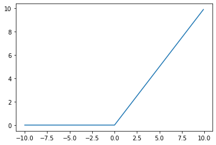

```python
# Create a relu object and make the prediction

RELU = nn.ReLU()
yhat = RELU(z)
plt.plot(z.numpy(), yhat.numpy())
```

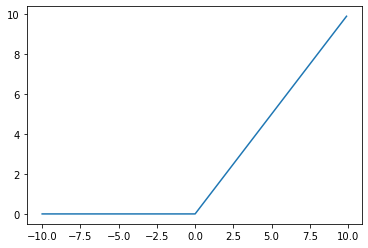

```python
# Use the build-in function to make the prediction

yhat = torch.relu(z)
plt.plot(z.numpy(), yhat.numpy())
plt.show()
```

## Compare Activation Functions

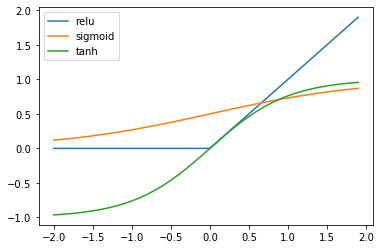

```python
# Plot the results to compare the activation functions

x = torch.arange(-2, 2, 0.1).view(-1, 1)
plt.plot(x.numpy(), torch.relu(x).numpy(), label='relu')
plt.plot(x.numpy(), torch.sigmoid(x).numpy(), label='sigmoid')
plt.plot(x.numpy(), torch.tanh(x).numpy(), label='tanh')
plt.legend()
```

## Practice

Compare the activation functions with a tensor in the range *(-1, 1)*

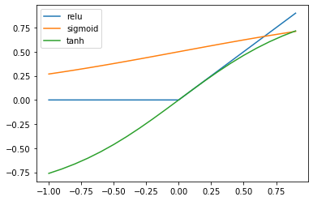

```python
# Practice: Compare the activation functions again using a tensor in the range (-1, 1)
x = torch.arange(-1, 1, 0.1).view(-1, 1)
plt.plot(x.numpy(), torch.relu(x).numpy(), label='relu')
plt.plot(x.numpy(), torch.sigmoid(x).numpy(), label='sigmoid')
plt.plot(x.numpy(), torch.tanh(x).numpy(), label='tanh')
plt.legend()
# Type your code here
```

[figure not shown]

## About the Authors:

[Joseph Santarcangelo](https://www.linkedin.com/in/joseph-s-50398b136/) has a PhD in Electrical Engineering, his research focused on using machine learning, signal processing, and computer vision to determine how videos impact human cognition. Joseph has been working for IBM since he completed his PhD.

Other contributors: [Michelle Carey](https://www.linkedin.com/in/michelleccarey/), Mavis Zhou

Copyright © 2018 cognitiveclass.ai. This notebook and its source code are released under the terms of the [MIT License](https://bigdatauniversity.com/mit-license/).